# Genes in Pathway Figures from CORD-19

Pathway knowledge extracted from CORD-19 dataset for the fight against COVID-19. This work is published under the CC0 waiver to be freely used and redistributed.

Link to repo with more information: https://github.com/wikipathways/cord-19

Important Note: This notebook is under active development to present knowledge resources and tools to help tackle the COVID-19 outbreak. **It is NOT a guide to public information.** The content presented here has **NOT** been filtered or reviewed.

## COVID-19 Open Research Dataset (CORD-19)

https://pages.semanticscholar.org/coronavirus-research

“In response to the COVID-19 pandemic, the Allen Institute for AI has partnered with leading research groups to prepare and distribute the COVID-19 Open Research Dataset (CORD-19), a free resource of over 29,000 scholarly articles, including over 13,000 with full text, about COVID-19 and the coronavirus family of viruses for use by the global research community.”

The PMC set of articles is based on this query.

*In total there are 9996 unique PMCIDs in CORD-19 collection (based on a filtering of the [metedata file](https://ai2-semanticscholar-cord-19.s3-us-west-2.amazonaws.com/2020-03-13/all_sources_metadata_2020-03-13.csv))*

## Pathway Figure OCR (PFOCR)

Independently, the [WikiPathways team](https://www.wikipathways.org/index.php/WikiPathways:Team), led by the [Pico group](https://profiles.ucsf.edu/alex.pico) at Gladstone has mined pathway figures at PMC from over the past 25 years (1995-2019) using a combination of image queries and machine learning, arriving at a set of 64,643 pathway figure images published and indexed by PMC.

```r
cord19.pfocr <- readRDS("cord19_pfocr.rds")
sprintf("Of the 9996 PMC papers in CORD-19, %i papers contain a total of %i pathway figures.", length(unique(cord19.pfocr$pmcid)), length(unique(cord19.pfocr$figid)))
```

```
[1] "Of the 9996 PMC papers in CORD-19, 189 papers contain a total of 221 pathway figures."
```

We then developed an entity recognition pipeline tailored for human gene mentions commonly found in pathway figures. This pipeline involves optical character recognition (OCR) followed by a series of normalizations and tranformations applied to the OCR output while matching against a custom lexicon of human gene symbols. *In addition to the genes we’ve recognized (as described below) we still have the raw OCR output as a JSON that may be of interest to the NLP community. We have collected the figure titles and captions associated with this set as well.*

```r
cord19.pfocr.genes <- readRDS("cord19_pfocr_genes.rds")
sprintf("Of the  %i pathway figures, we could identify one or more genes from %i of them among %i PMC papers.", length(unique(cord19.pfocr$figid)), length(unique(cord19.pfocr.genes$figid)), length(unique(cord19.pfocr.genes$pmcid)))
```

```
[1] "Of the  221 pathway figures, we could identify one or more genes from 216 of them among 184 PMC papers."
```

```r
sprintf("These %i pathway figures contain a total of %i gene mentions mapping to %i unique gene identifiers (NCBI Gene Entrez IDs).", length(unique(cord19.pfocr.genes$figid)), length(cord19.pfocr.genes$symbol), length(unique(cord19.pfocr.genes$entrez)))
```

```
[1] "These 216 pathway figures contain a total of 4818 gene mentions mapping to 1523 unique gene identifiers (NCBI Gene Entrez IDs)."
```

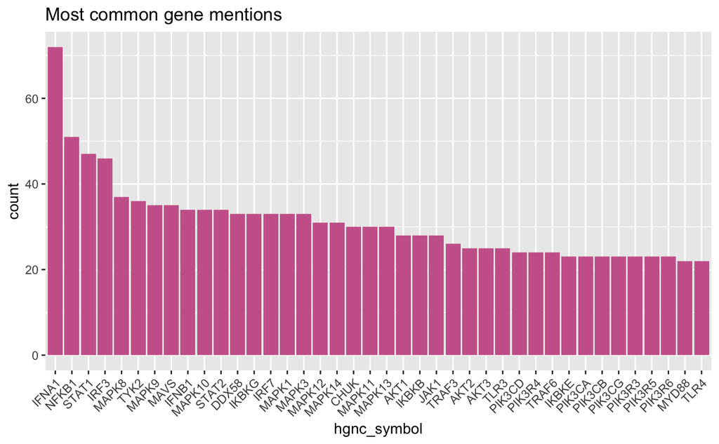

```r
library(dplyr)
library(tidyr)
library(ggplot2)
cord19.pfocr.genes.cnt <- cord19.pfocr.genes %>%
  group_by(hgnc_symbol) %>%
  summarise(count = n()) %>%
  arrange(desc(count), hgnc_symbol)

cord19.pfocr.genes.cnt$hgnc_symbol <- factor(cord19.pfocr.genes.cnt$hgnc_symbol, levels = cord19.pfocr.genes.cnt$hgnc_symbol)

p <- cord19.pfocr.genes.cnt %>%
  top_n(40) %>%
  ggplot(aes(hgnc_symbol, count)) +
  geom_bar(fill = "#CC6699", stat = "identity") +
  theme(axis.text.x = element_text(angle = 45, hjust = 1)) +
  ggtitle("Most common gene mentions")
print(p)
```

We have perfomed disease enrichment analysis against these figure-based gene sets to characterize their collective functions. We used the filtered “knowledge” set from [Jensen’s Diseases resource](https://diseases.jensenlab.org/Downloads).

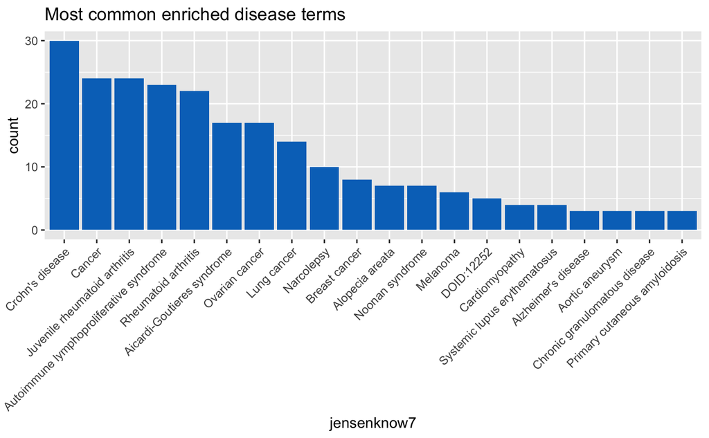

```r
cord19.pfocr.diseases <- readRDS("cord19_pfocr_diseases.rds")

cord19.pfocr.diseases.cnt <- cord19.pfocr.diseases %>%
  group_by(jensenknow7) %>%
  summarise(count = n()) %>%
  arrange(desc(count), jensenknow7)

cord19.pfocr.diseases.cnt$jensenknow7 <- factor(cord19.pfocr.diseases.cnt$jensenknow7, levels = cord19.pfocr.diseases.cnt$jensenknow7)

p <- cord19.pfocr.diseases.cnt %>%
  top_n(20) %>%
  ggplot(aes(jensenknow7, count)) +
  geom_bar(fill = "#0073C2FF", stat = "identity") +
  theme(axis.text.x = element_text(angle = 45, hjust = 1)) +
  ggtitle("Most common enriched disease terms")
print(p)
```

Other than overlap with cancer-related signaling pathways, we observe a lot of auto-immune disease hits like Crohn’s, RA, Alopecia areata and Lupus.